# Predictive Analysis with Text

This dataset is based on a set of Amazon review of video games downloaded from Prof. Julian McAuley’s [website](https://cseweb.ucsd.edu/~jmcauley/). The original json dataset was parsed into a dataframe and cleaned. Since this dataset is very large, I have only included data from Aug 2013 to July 2014 which gives us a year of data to work with. Also we are only using data on three fields, id, review and review rating. Finally, three blank reviews were dropped from the data. The data we are going to use includes the following fields:

- id: A unique identifier for each review
- review: Text of review posted on Amazon
- review_rating: Each review on Amazon is rated by others using a five-star scale (presumably based on helpfulness of review)

## Read Data

```python
import pandas as pd
data = pd.read_csv('video_game_reviews.csv').set_index('id')
data.head()
```

| id | review | review_rating |
| --- | --- | --- |
| 1 | 1st shipment received a book instead of the ga... | 1 |
| 2 | I still haven't figured this one out. Did ever... | 2 |
| 3 | I bought this and the key didn't work. It was... | 1 |
| 4 | I love it! Use it all the time. Really works p... | 5 |
| 5 | my grandkids (and their parents) love playing ... | 5 |

## Split Data

```python
from sklearn.model_selection import train_test_split
X = data.review
y = data.review_rating
X_train, X_test, y_train, y_test = train_test_split(X,y,train_size=0.7, random_state=1031)
print(X_train.head())
print(y_train.head())
```

```
id
2601     This game got boring within 20 minutes of play...
11604    It is a great game, but the plot is just so la...
3105     In 2002, the Sting Entertainment-developed Yak...
5270     I love the Mortimer Beckett puzzles but let me...
21767    Coming from the bitter taste of disappointment...
Name: review, dtype: object
id
2601     1
11604    4
3105     4
5270     3
21767    4
Name: review_rating, dtype: int64
```

## Words to Features

One of the most popular methods for converting text to features is the Bag of Words approach. This is a two-step process that involves

- Tokenizing text
- Quantifying tokens

The bag of words approach used will vary based on how these two steps are carried out. Specifically,

- Tokenizing Text: Corpus of text may be broken into paragraphs, sentences, words, or letters. Furthermore, a token may represent one (1-gram) or more units (n-gram).
- Quantifying Tokens: Tokens may be quantified based on their frequency of occurence (term-frequency) or as a product of frequency of occurrence in a document and relative frequency across all documents (term-frequency inverse document frequency)

### Tokenizing text

- .split()
- nltk.tokenize functions
- re regular expressions

```python
text = "   Rohan's favorite event is 100 yard Breast Stroke. Nikhil's favorite stroke is Back Stroke.   "
text.strip().split(' ')
```

```
["Rohan's",
 'favorite',
 'event',
 'is',
 '100',
 'yard',
 'Breast',
 'Stroke.',
 "Nikhil's",
 'favorite',
 'stroke',
 'is',
 'Back',
 'Stroke.']
```

```python
from nltk.tokenize import sent_tokenize, word_tokenize,wordpunct_tokenize,regexp_tokenize
sent_tokenize(text)
word_tokenize(text)
wordpunct_tokenize(text)
regexp_tokenize(text, r'.')
```

```
[' ',
 ' ',
 ' ',
 'R',
 'o',
 'h',
 'a',
 'n',
 "'",
 's',
 ' ',
 'f',
 'a',
 'v',
 'o',
 'r',
 'i',
 't',
 'e',
 ' ',
 'e',
 'v',
 'e',
 'n',
 't',
 ' ',
 'i',
 's',
 ' ',
 '1',
 '0',
 '0',
 ' ',
 'y',
 'a',
 'r',
 'd',
 ' ',
 'B',
 'r',
```

[output cut: 41 more lines]

```
 'B',
 'a',
 'c',
 'k',
 ' ',
 'S',
 't',
 'r',
 'o',
 'k',
 'e',
 '.',
 ' ',
 ' ',
 ' ']
```

```python
import spacy
nlp = spacy.load('en_core_web_sm')
doc = nlp(text)
[token.text for token in doc]
```

```
['   ',
 'Rohan',
 "'s",
 'favorite',
 'event',
 'is',
 '100',
 'yard',
 'Breast',
 'Stroke',
 '.',
 'Nikhil',
 "'s",
 'favorite',
 'stroke',
 'is',
 'Back',
 'Stroke',
 '.',
 '  ']
```

```python
[token.pos_ for token in doc]
```

```
['SPACE',
 'PROPN',
 'PART',
 'ADJ',
 'NOUN',
 'AUX',
 'NUM',
 'NOUN',
 'PROPN',
 'PROPN',
 'PUNCT',
 'PROPN',
 'PART',
 'ADJ',
 'NOUN',
 'AUX',
 'ADV',
 'PROPN',
 'PUNCT',
 'SPACE']
```

### Quantifying Tokens

- collections Counter
- sklearn.feature_extraction.text CountVectorizer, TfidfVectorizer
- spaCy

```python
text = ["   Rohan's favorite event is 100 yard Breast Stroke.",
        " Nikhil's favorite stroke is Back Stroke.   "]
from nltk.tokenize import word_tokenize
from collections import Counter
tokens = [word_tokenize(sent) for sent in text]
tokens_count = [Counter(word_tokenize(sent)) for sent in text]
tokens_count
```

```
[Counter({'Rohan': 1,
          "'s": 1,
          'favorite': 1,
          'event': 1,
          'is': 1,
          '100': 1,
          'yard': 1,
          'Breast': 1,
          'Stroke': 1,
          '.': 1}),
 Counter({'Nikhil': 1,
          "'s": 1,
          'favorite': 1,
          'stroke': 1,
          'is': 1,
          'Back': 1,
          'Stroke': 1,
          '.': 1})]
```

```python
from sklearn.feature_extraction.text import CountVectorizer, TfidfVectorizer
tf_vectorizer = CountVectorizer(lowercase = False)
```

```python
text = ["   Rohan's favorite event is 100 yard Breast Stroke.", "Nikhil's favorite stroke is Back Stroke.   "]
tf_vectorizer.fit_transform(text)
```

```
<Compressed Sparse Row sparse matrix of dtype 'int64'
    with 14 stored elements and shape (2, 11)>
```

```python
matrix = tf_vectorizer.fit_transform(text).toarray()
tokens = tf_vectorizer.get_feature_names_out()
pd.DataFrame(matrix, columns=tokens)
```

|  | 100 | Back | Breast | Nikhil | Rohan | Stroke | event | favorite | is | stroke | yard |
| --- | --- | --- | --- | --- | --- | --- | --- | --- | --- | --- | --- |
| 0 | 1 | 0 | 1 | 0 | 1 | 1 | 1 | 1 | 1 | 0 | 1 |
| 1 | 0 | 1 | 0 | 1 | 0 | 1 | 0 | 1 | 1 | 1 | 0 |

## Document Term Matrix

- Tokenize
- Quantify
- Convert to Matrix

```python
tf_vectorizer = CountVectorizer(lowercase = True, stop_words = 'english',ngram_range=(1,1))
tf_vectorizer.fit(X_train)
X_train_tf = tf_vectorizer.transform(X_train)
X_test_tf = tf_vectorizer.transform(X_test)
```

#### Term Frequency based Document Term Matrix

```python
pd.DataFrame(X_train_tf.toarray(),columns=tf_vectorizer.get_feature_names_out())
```

|  | 00 | 000 | 00002 | 000msp | 001 | 001from | 007 | 00i | 00point | 00s | ... | zss | zuba | zumba | zwei | zweihander | zweihanders | zygarde | zzzz | zzzzzzz | zzzzzzzz |
| --- | --- | --- | --- | --- | --- | --- | --- | --- | --- | --- | --- | --- | --- | --- | --- | --- | --- | --- | --- | --- | --- |
| 0 | 0 | 0 | 0 | 0 | 0 | 0 | 0 | 0 | 0 | 0 | ... | 0 | 0 | 0 | 0 | 0 | 0 | 0 | 0 | 0 | 0 |
| 1 | 0 | 0 | 0 | 0 | 0 | 0 | 0 | 0 | 0 | 0 | ... | 0 | 0 | 0 | 0 | 0 | 0 | 0 | 0 | 0 | 0 |
| 2 | 0 | 0 | 0 | 0 | 0 | 0 | 0 | 0 | 0 | 0 | ... | 0 | 0 | 0 | 0 | 0 | 0 | 0 | 0 | 0 | 0 |
| 3 | 0 | 0 | 0 | 0 | 0 | 0 | 0 | 0 | 0 | 0 | ... | 0 | 0 | 0 | 0 | 0 | 0 | 0 | 0 | 0 | 0 |
| 4 | 0 | 0 | 0 | 0 | 0 | 0 | 0 | 0 | 0 | 0 | ... | 0 | 0 | 0 | 0 | 0 | 0 | 0 | 0 | 0 | 0 |
| ... | ... | ... | ... | ... | ... | ... | ... | ... | ... | ... | ... | ... | ... | ... | ... | ... | ... | ... | ... | ... | ... |
| 18651 | 0 | 0 | 0 | 0 | 0 | 0 | 0 | 0 | 0 | 0 | ... | 0 | 0 | 0 | 0 | 0 | 0 | 0 | 0 | 0 | 0 |
| 18652 | 0 | 0 | 0 | 0 | 0 | 0 | 0 | 0 | 0 | 0 | ... | 0 | 0 | 0 | 0 | 0 | 0 | 0 | 0 | 0 | 0 |
| 18653 | 0 | 0 | 0 | 0 | 0 | 0 | 0 | 0 | 0 | 0 | ... | 0 | 0 | 0 | 0 | 0 | 0 | 0 | 0 | 0 | 0 |
| 18654 | 0 | 0 | 0 | 0 | 0 | 0 | 0 | 0 | 0 | 0 | ... | 0 | 0 | 0 | 0 | 0 | 0 | 0 | 0 | 0 | 0 |
| 18655 | 0 | 0 | 0 | 0 | 0 | 0 | 0 | 0 | 0 | 0 | ... | 0 | 0 | 0 | 0 | 0 | 0 | 0 | 0 | 0 | 0 |

18656 rows × 36338 columns

```python
from sklearn.feature_extraction.text import TfidfVectorizer
tfidf_vectorizer = TfidfVectorizer(stop_words='english',lowercase=True, ngram_range=(1,1))
tfidf_vectorizer.fit(X_train)
X_train_tfidf = tfidf_vectorizer.transform(X_train)
X_test_tfidf = tfidf_vectorizer.transform(X_test)
```

#### Term Frequency - Inverse Document Frequency based Document Term Matrix

```python
pd.DataFrame(X_train_tfidf.toarray(), columns = tfidf_vectorizer.get_feature_names_out())
```

|  | 00 | 000 | 00002 | 000msp | 001 | 001from | 007 | 00i | 00point | 00s | ... | zss | zuba | zumba | zwei | zweihander | zweihanders | zygarde | zzzz | zzzzzzz | zzzzzzzz |
| --- | --- | --- | --- | --- | --- | --- | --- | --- | --- | --- | --- | --- | --- | --- | --- | --- | --- | --- | --- | --- | --- |
| 0 | 0.0 | 0.0 | 0.0 | 0.0 | 0.0 | 0.0 | 0.0 | 0.0 | 0.0 | 0.0 | ... | 0.0 | 0.0 | 0.0 | 0.0 | 0.0 | 0.0 | 0.0 | 0.0 | 0.0 | 0.0 |
| 1 | 0.0 | 0.0 | 0.0 | 0.0 | 0.0 | 0.0 | 0.0 | 0.0 | 0.0 | 0.0 | ... | 0.0 | 0.0 | 0.0 | 0.0 | 0.0 | 0.0 | 0.0 | 0.0 | 0.0 | 0.0 |
| 2 | 0.0 | 0.0 | 0.0 | 0.0 | 0.0 | 0.0 | 0.0 | 0.0 | 0.0 | 0.0 | ... | 0.0 | 0.0 | 0.0 | 0.0 | 0.0 | 0.0 | 0.0 | 0.0 | 0.0 | 0.0 |
| 3 | 0.0 | 0.0 | 0.0 | 0.0 | 0.0 | 0.0 | 0.0 | 0.0 | 0.0 | 0.0 | ... | 0.0 | 0.0 | 0.0 | 0.0 | 0.0 | 0.0 | 0.0 | 0.0 | 0.0 | 0.0 |
| 4 | 0.0 | 0.0 | 0.0 | 0.0 | 0.0 | 0.0 | 0.0 | 0.0 | 0.0 | 0.0 | ... | 0.0 | 0.0 | 0.0 | 0.0 | 0.0 | 0.0 | 0.0 | 0.0 | 0.0 | 0.0 |
| ... | ... | ... | ... | ... | ... | ... | ... | ... | ... | ... | ... | ... | ... | ... | ... | ... | ... | ... | ... | ... | ... |
| 18651 | 0.0 | 0.0 | 0.0 | 0.0 | 0.0 | 0.0 | 0.0 | 0.0 | 0.0 | 0.0 | ... | 0.0 | 0.0 | 0.0 | 0.0 | 0.0 | 0.0 | 0.0 | 0.0 | 0.0 | 0.0 |
| 18652 | 0.0 | 0.0 | 0.0 | 0.0 | 0.0 | 0.0 | 0.0 | 0.0 | 0.0 | 0.0 | ... | 0.0 | 0.0 | 0.0 | 0.0 | 0.0 | 0.0 | 0.0 | 0.0 | 0.0 | 0.0 |
| 18653 | 0.0 | 0.0 | 0.0 | 0.0 | 0.0 | 0.0 | 0.0 | 0.0 | 0.0 | 0.0 | ... | 0.0 | 0.0 | 0.0 | 0.0 | 0.0 | 0.0 | 0.0 | 0.0 | 0.0 | 0.0 |
| 18654 | 0.0 | 0.0 | 0.0 | 0.0 | 0.0 | 0.0 | 0.0 | 0.0 | 0.0 | 0.0 | ... | 0.0 | 0.0 | 0.0 | 0.0 | 0.0 | 0.0 | 0.0 | 0.0 | 0.0 | 0.0 |
| 18655 | 0.0 | 0.0 | 0.0 | 0.0 | 0.0 | 0.0 | 0.0 | 0.0 | 0.0 | 0.0 | ... | 0.0 | 0.0 | 0.0 | 0.0 | 0.0 | 0.0 | 0.0 | 0.0 | 0.0 | 0.0 |

18656 rows × 36338 columns

## Fit Model

### Decision Tree

```python
from sklearn.tree import DecisionTreeRegressor, plot_tree
tree = DecisionTreeRegressor(random_state=1031)
tree.fit(X_train_tf, y_train)
```

```
DecisionTreeRegressor(random_state=1031)
```

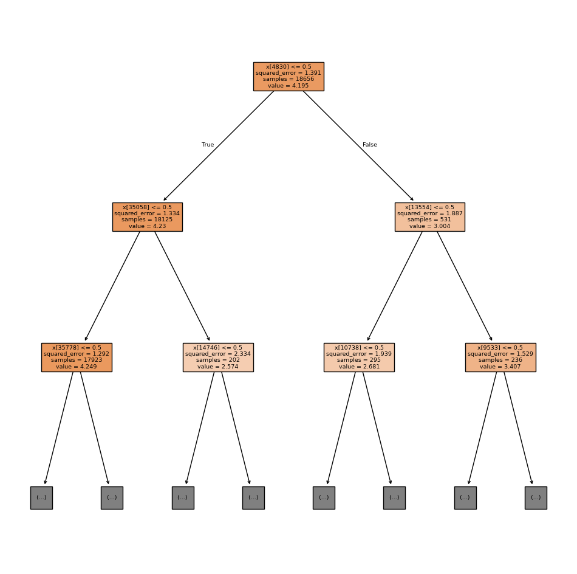

```python
import matplotlib.pyplot as plt
plt.figure(figsize = (12,12))
plot_tree(tree,max_depth=2,filled=True,)
plt.show()
```

```python
tf_vectorizer.get_feature_names_out()[4830]
```

```
'boring'
```

### Linear Regression

Linear Regression is destined to fail because of the number of features!

```python
X_train_tf.shape
```

```
(18656, 36338)
```

```python
from sklearn.linear_model import LinearRegression
lm = LinearRegression()
lm.fit(X_train_tf, y_train)
```

```
LinearRegression()
```

```python
coefficients = pd.DataFrame(lm.coef_, columns=['coefficients'])
coefficients.index = tf_vectorizer.get_feature_names_out()
coefficients.abs().sort_values(['coefficients'],ascending = False)
```

|  | coefficients |
| --- | --- |
| fluctuate | 28.996029 |
| unaware | 27.967287 |
| scanner | 27.057213 |
| inventively | 26.832820 |
| confession | 25.335647 |
| ... | ... |
| animes | 0.000354 |
| 23 | 0.000294 |
| wanna | 0.000242 |
| granddaughters | 0.000067 |
| constructionthe | 0.000032 |

36338 rows × 1 columns

## Evaluate Model

### Decision Tree

```python
from sklearn.metrics import root_mean_squared_error
pred = tree.predict(X_test_tf)
root_mean_squared_error(y_test, pred)
```

```
1.3715102397644736
```

### Linear Regression

```python
from sklearn.metrics import root_mean_squared_error
pred = lm.predict(X_test_tf)
root_mean_squared_error(y_test, pred)
```

```
13.48443547386001
```

## Summary

In this note, we extracted features from a corpus of text and then used those features to fit a predictive model.

This file was generated using Python 3.11.13 on Windows 10 with the following libraries: matplotlib 3.10.0, nltk 3.9.1, numpy 1.26.4, pandas 2.3.1, scikit-learn 1.7.1, spacy 3.7.2